# Regresja liniowa prosta

```r
carseats <- tibble::as.tibble(ISLR::Carseats)
head(carseats)
```

| Sales | CompPrice | Income | Advertising | Population | Price | ShelveLoc | Age | Education | Urban | US |
| --- | --- | --- | --- | --- | --- | --- | --- | --- | --- | --- |
| 9.50 | 138 | 73 | 11 | 276 | 120 | Bad | 42 | 17 | Yes | Yes |
| 11.22 | 111 | 48 | 16 | 260 | 83 | Good | 65 | 10 | Yes | Yes |
| 10.06 | 113 | 35 | 10 | 269 | 80 | Medium | 59 | 12 | Yes | Yes |
| 7.40 | 117 | 100 | 4 | 466 | 97 | Medium | 55 | 14 | Yes | Yes |
| 4.15 | 141 | 64 | 3 | 340 | 128 | Bad | 38 | 13 | Yes | No |
| 10.81 | 124 | 113 | 13 | 501 | 72 | Bad | 78 | 16 | No | Yes |

```r
dim(carseats)
```

```
## [1] 400  11
```

# Opis danych

Zaczniemy od opisania naszego zbioru danych. Zbiór ten posiada 400 wierszy oraz 11 kolumn które dotyczą sprzedaży fotelików samochodowych. Opiszemy co oznaczają poszczególne kolumny.  
**Sales**: Sprzedaż fotelików w tysiącach jednostek.  
**CompPrice**: Cena konkurencyjnego produktu w danym regionie.  
**Income**: Średni dochód w regionie (w tysiącach dolarów).  
**Advertising**: Budżet reklamowy w danym regionie (w tysiącach dolarów).  
**Population**: Populacja w regionie (w tysiącach).  
**Price**: Cena fotelika.  
**ShelveLoc**: Lokalizacja półki z fotelikami (kategorie: *Bad*, *Good*, *Medium*).  
**Age**: Średni wiek mieszkańców w regionie.  
**Education**: Średni poziom edukacji w regionie.  
**Urban**: Zmienna wskazująca, czy region jest miejski (*Yes*) lub wiejski (*No*).  
**US**: Zmienna wskazująca, czy region znajduje się w USA (*Yes*) lub poza USA (*No*).  
Nastepnie policzymy podstawowe statystyki dla naszych danych.

```r
summary(carseats)
```

```
##      Sales          CompPrice       Income        Advertising
##  Min.   : 0.000   Min.   : 77   Min.   : 21.00   Min.   : 0.000
##  1st Qu.: 5.390   1st Qu.:115   1st Qu.: 42.75   1st Qu.: 0.000
##  Median : 7.490   Median :125   Median : 69.00   Median : 5.000
##  Mean   : 7.496   Mean   :125   Mean   : 68.66   Mean   : 6.635
##  3rd Qu.: 9.320   3rd Qu.:135   3rd Qu.: 91.00   3rd Qu.:12.000
##  Max.   :16.270   Max.   :175   Max.   :120.00   Max.   :29.000
##    Population        Price        ShelveLoc        Age          Education
##  Min.   : 10.0   Min.   : 24.0   Bad   : 96   Min.   :25.00   Min.   :10.0
##  1st Qu.:139.0   1st Qu.:100.0   Good  : 85   1st Qu.:39.75   1st Qu.:12.0
##  Median :272.0   Median :117.0   Medium:219   Median :54.50   Median :14.0
##  Mean   :264.8   Mean   :115.8                Mean   :53.32   Mean   :13.9
##  3rd Qu.:398.5   3rd Qu.:131.0                3rd Qu.:66.00   3rd Qu.:16.0
##  Max.   :509.0   Max.   :191.0                Max.   :80.00   Max.   :18.0
##  Urban       US
##  No :118   No :142
##  Yes:282   Yes:258
##
##
##
##
```

Zbadamy zależności między zmiennymi objaśniającymi, a zmienną Sales poprzez wykresy punktowe oraz obliczenie korelacji Pearsona.

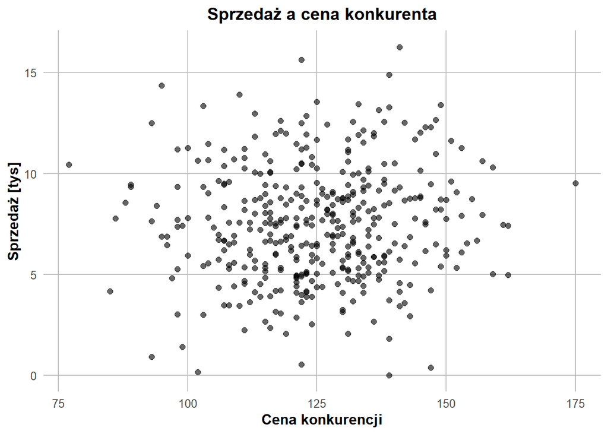

```r
ggplot(carseats, aes(x = CompPrice, y = Sales)) + geom_point(size = 2, color = "black", alpha = 0.6) +
  labs(title = 'Sprzedaż a cena konkurenta', x = 'Cena konkurencji', y = 'Sprzedaż [tys]') +  theme_minimal(base_size = 12) +
  theme(
    plot.title = element_text(hjust = 0.5, face = "bold"),
    axis.title = element_text(face = "bold"),
    panel.grid.major = element_line(color = "gray", size = 0.5),
    panel.grid.minor = element_blank()
  )
```

```r
cor(carseats$CompPrice, carseats$Sales)
```

```
## [1] 0.06407873
```

Możemy zauważyć, że istnieje bardzo znikoma korelacja między sprzedażą a ceną u konkurencji. Co może sugerować, że cena konkurencji nie ma istotnego wpływu na sprzedaż w naszym przypadku.

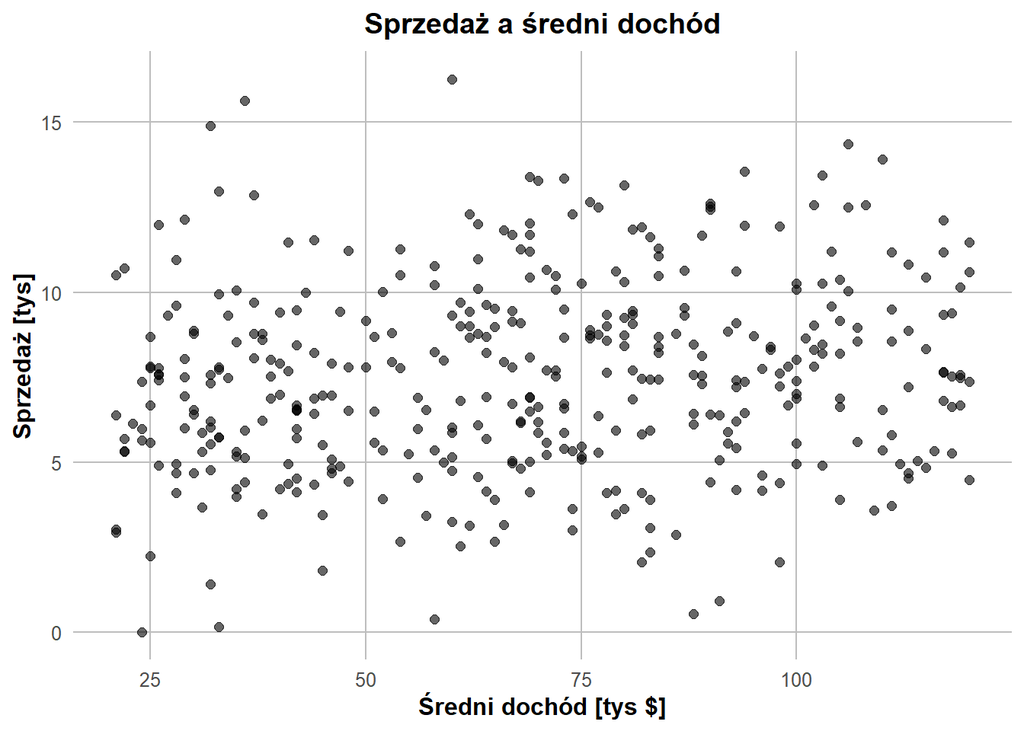

```r
ggplot(carseats, aes(x = Income, y = Sales)) + geom_point(size = 2, color = "black", alpha = 0.6) +
  labs(title = 'Sprzedaż a średni dochód', x = 'Średni dochód [tys $]', y = 'Sprzedaż [tys]') + theme_minimal(base_size = 12) +
  theme(
    plot.title = element_text(hjust = 0.5, face = "bold"),
    axis.title = element_text(face = "bold"),
    panel.grid.major = element_line(color = "gray", size = 0.5),
    panel.grid.minor = element_blank()
  )
```

```r
cor(carseats$Income, carseats$Sales)
```

```
## [1] 0.151951
```

Sprzedaż oraz dochód w danym obszarze wykazują bardzo niską korelację dodatnią. Sugeruje to, że związek między zmiennymi jest znikomy.

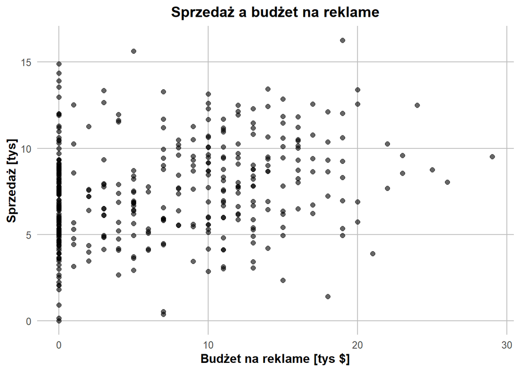

```r
ggplot(carseats, aes(x = Advertising, y = Sales)) + geom_point(size = 2, color = "black", alpha = 0.6) +
  labs(title = 'Sprzedaż a budżet na reklame', x = 'Budżet na reklame [tys $]', y = 'Sprzedaż [tys]') + theme_minimal(base_size = 12) +
  theme(
    plot.title = element_text(hjust = 0.5, face = "bold"),
    axis.title = element_text(face = "bold"),
    panel.grid.major = element_line(color = "gray", size = 0.5),
    panel.grid.minor = element_blank()
  )
```

```r
cor(carseats$Advertising, carseats$Sales)
```

```
## [1] 0.2695068
```

Budżet reklamowy oraz sprzedaż wykazują wyraźniejszy związek niż dwie powyższe lecz nie jest on silny. Może wskazywać na to, że wieksze wydatki na reklamę mogą stymulować popyt.

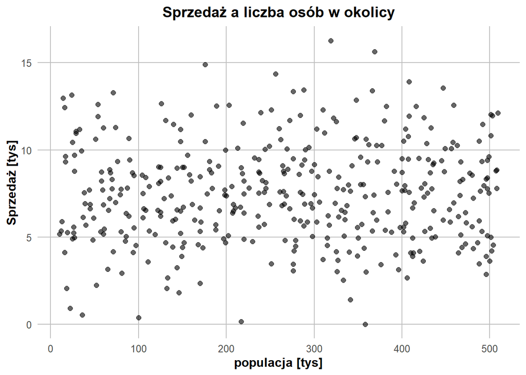

```r
ggplot(carseats, aes(x = Population, y = Sales)) + geom_point(size = 2, color = "black", alpha = 0.6) +
  labs(title = 'Sprzedaż a liczba osób w okolicy', x = 'populacja [tys]', y = 'Sprzedaż [tys]') + theme_minimal(base_size = 12) +
  theme(
    plot.title = element_text(hjust = 0.5, face = "bold"),
    axis.title = element_text(face = "bold"),
    panel.grid.major = element_line(color = "gray", size = 0.5),
    panel.grid.minor = element_blank()
  )
```

```r
cor(carseats$Population, carseats$Sales)
```

```
## [1] 0.05047098
```

Wielkosc populacji w danym regionie nie ma istotnego wpływu na sprzedaż.

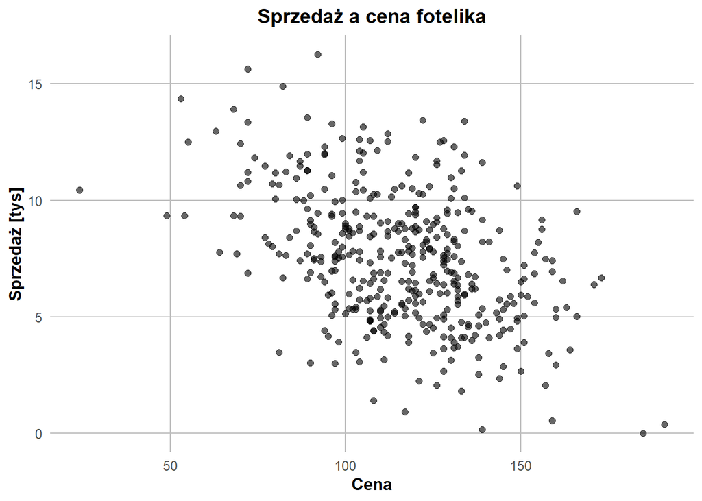

```r
ggplot(carseats, aes(x = Price, y = Sales)) + geom_point(size = 2, color = "black", alpha = 0.6) +
  labs(title = 'Sprzedaż a cena fotelika', x = 'Cena', y = 'Sprzedaż [tys]') + theme_minimal(base_size = 12) +
  theme(
    plot.title = element_text(hjust = 0.5, face = "bold"),
    axis.title = element_text(face = "bold"),
    panel.grid.major = element_line(color = "gray", size = 0.5),
    panel.grid.minor = element_blank()
  )
```

```r
cor(carseats$Price, carseats$Sales)
```

```
## [1] -0.4449507
```

Cena fotelika oraz sprzedaż wykazują ujemna korelacje. Co sugeruje, że wraz ze wzrostem ceny sprzedaż może mieć tendencje do spadków.

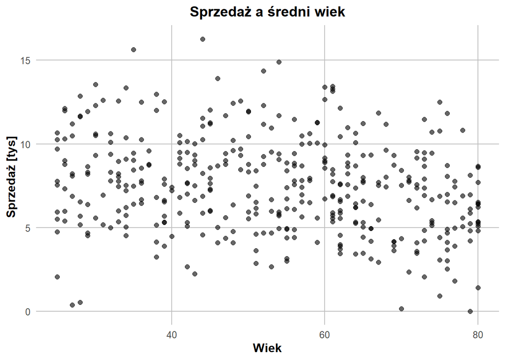

```r
ggplot(carseats, aes(x = Age, y = Sales)) + geom_point(size = 2, color = "black", alpha = 0.6) +
  labs(title = 'Sprzedaż a średni wiek', x = 'Wiek', y = 'Sprzedaż [tys] ') + theme_minimal(base_size = 12) +
  theme(
    plot.title = element_text(hjust = 0.5, face = "bold"),
    axis.title = element_text(face = "bold"),
    panel.grid.major = element_line(color = "gray", size = 0.5),
    panel.grid.minor = element_blank()
  )
```

```r
cor(carseats$Age, carseats$Sales)
```

```
## [1] -0.2318154
```

średni wiek mieszkańców w regionie oraz sprzedaż wykazują słabą ujemną korelację, co może oznaczać, że na obszarach z wyższym średnim wiekiem może wystąpic mniejsza sprzedaż.

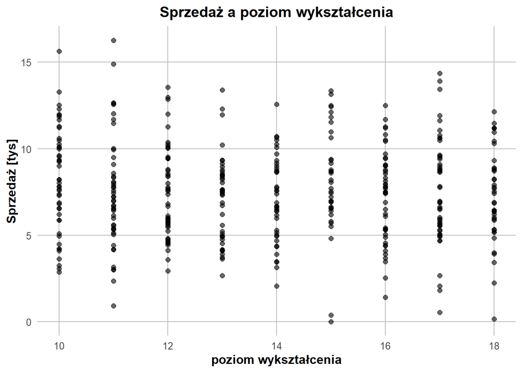

```r
ggplot(carseats, aes(x = Education, y = Sales)) + geom_point(size = 2, color = "black", alpha = 0.6) +
  labs(title = 'Sprzedaż a poziom wykształcenia', x = 'poziom wykształcenia', y = 'Sprzedaż [tys]') + theme_minimal(base_size = 12) +
  theme(
    plot.title = element_text(hjust = 0.5, face = "bold"),
    axis.title = element_text(face = "bold"),
    panel.grid.major = element_line(color = "gray", size = 0.5),
    panel.grid.minor = element_blank()
  )
```

```r
cor(carseats$Education, carseats$Sales)
```

```
## [1] -0.05195524
```

Możemy zauważyć ze zmienne wykazują bardzo znikomą korelację ujemną wskazując na to, że poziom wykształcenia nie wpływa na sprzedaż.  
Zobaczymy jak prezentują się zmienne kategorialne.

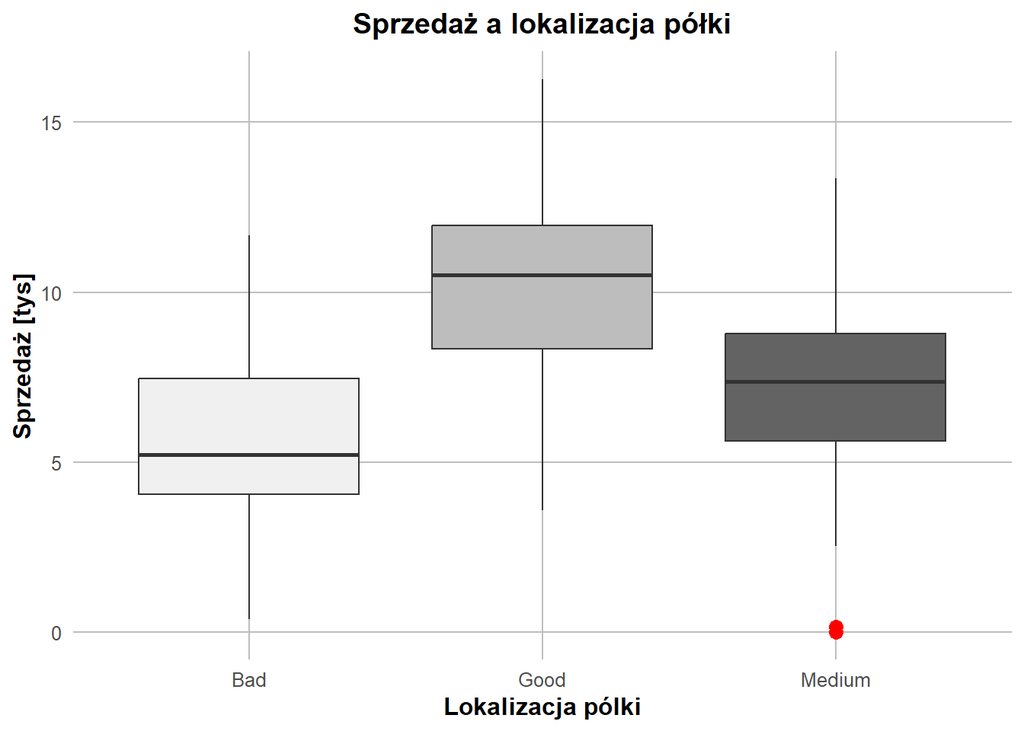

```r
ggplot(Carseats, aes(x=ShelveLoc, y=Sales, fill=ShelveLoc)) + geom_boxplot(outlier.color='red', outlier.size=3) +
  scale_fill_brewer(palette = "Greys") +
  labs(title = "Sprzedaż a lokalizacja półki", x = "Lokalizacja pólki", y = "Sprzedaż [tys]") +
  theme_minimal(base_size = 12) +
  theme(
    plot.title = element_text(hjust = 0.5, face = "bold"),
    axis.title = element_text(face = "bold"),
    panel.grid.major = element_line(color = "gray", size = 0.5),
    panel.grid.minor = element_blank(),
    legend.position = "none"
  )
```

Możemy zauważyć, że coraz lepsza lokalizacja półki w sklepie wykazuje najlepszą sprzedaż.

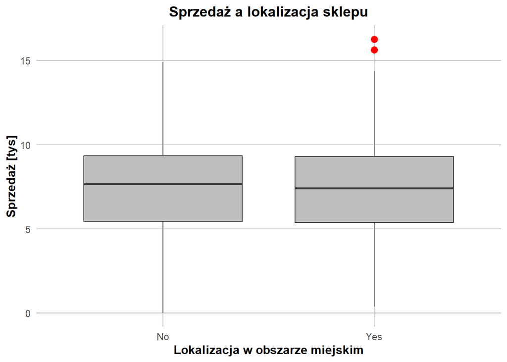

```r
ggplot(Carseats, aes(x=Urban, y=Sales)) + geom_boxplot(fill='grey', outlier.color='red', outlier.size=3) +
  labs(title = "Sprzedaż a lokalizacja sklepu", x = "Lokalizacja w obszarze miejskim", y = "Sprzedaż [tys]") +
  theme_minimal(base_size = 12) +
  theme(
    plot.title = element_text(hjust = 0.5, face = "bold"),
    axis.title = element_text(face = "bold"),
    panel.grid.major = element_line(color = "gray", size = 0.5),
    panel.grid.minor = element_blank()
  )
```

Znikoma różnica między sklepami znajdującymi się w mieście a sklepami poza miastem.

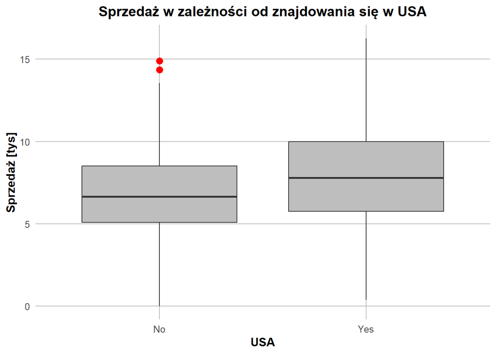

```r
ggplot(Carseats, aes(x=US, y=Sales)) + geom_boxplot(fill='grey', outlier.color='red', outlier.size=3) +
  labs(title="Sprzedaż w zależności od znajdowania się w USA", x='USA', y='Sprzedaż [tys]') +
  theme_minimal(base_size = 12) +
  theme(
    plot.title = element_text(hjust = 0.5, face = "bold"),
    axis.title = element_text(face = "bold"),
    panel.grid.major = element_line(color = "gray", size = 0.5),
    panel.grid.minor = element_blank()
  )
```

Sklepy znajdujące się w USA mają minimalnie wyższą sprzedaż

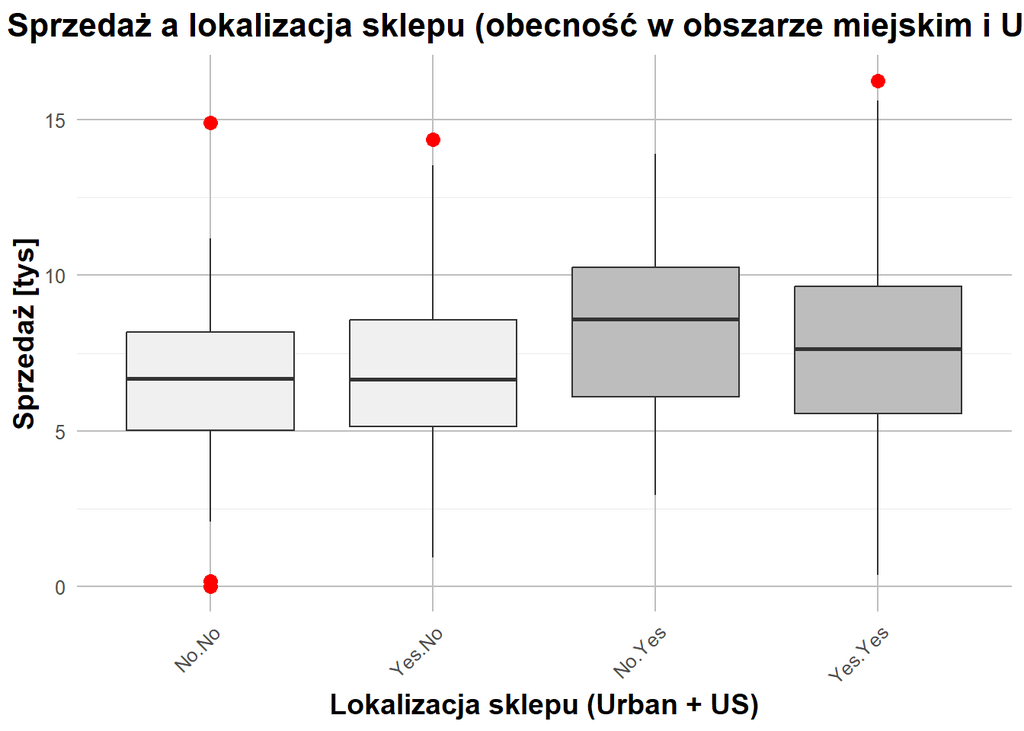

```r
ggplot(Carseats, aes(x = interaction(Urban, US), y = Sales, fill = US)) +
  geom_boxplot(outlier.color = 'red', outlier.size = 3) +
  scale_fill_brewer(palette = "Greys") +
  labs(title = "Sprzedaż a lokalizacja sklepu (obecność w obszarze miejskim i USA)",
       x = "Lokalizacja sklepu (Urban + US)",
       y = "Sprzedaż [tys]") +
  theme_minimal(base_size = 12) +
  theme(
    plot.title = element_text(hjust = 0.5, face = "bold", size = 16),
    axis.title = element_text(face = "bold", size = 14),
    panel.grid.major = element_line(color = "gray", size = 0.5),
    legend.position = "none",
    axis.text.x = element_text(angle = 45, hjust = 1)
  )
```

```r
cor(Carseats %>% select_if(is.numeric))["Sales", -which(colnames(Carseats) == "Sales")]
```

```
##   CompPrice      Income Advertising  Population       Price         Age
##  0.06407873  0.15195098  0.26950678  0.05047098 -0.44495073 -0.23181544
##   Education
## -0.05195524
```

Zwróćmy uwagę na to, że korelacja zmiennej Sales z zmiennymi CompPrice, Population i Education jest bliska 0, więc już teraz możemy stwierdzić, że modele regresji liniowej prostej z tymi zmiennymi objaśniającymi nie będą miały dobrej jakości.

# Dopasowanie oraz analiza modeli

Dopasujemy teraz modele regresji liniowej przewidujące wartość zmiennej Sales oraz zbadamy poniższe założenia:

1. Zależność liniowa między zmiennymi
2. Rozkład reszt mający rozkład normalny
3. Zerowa średnia reszt
4. Niezależność reszt
5. Homoskedastyczność stała wariancja błędów

```r
#podzielenie zbioru na zbiór treningowy i zbiór testowy
set.seed(44)
partition <- caret::createDataPartition(carseats$Sales, list=FALSE, p=0.75)
carseats_train <- carseats[partition,]
carseats_test <- carseats[-partition,]
```

```r
print(dim(carseats_train))
```

```
## [1] 301  11
```

```r
print(dim(carseats_test))
```

```
## [1] 99 11
```

```r
MAPE <- function(y_actual, y_predicted) {
  y_actual[y_actual == 0] <- NA  # Obsługa potencjalnych zer w mianowniku
  return(mean(abs((y_actual - y_predicted) / y_actual), na.rm = TRUE) * 100)
}
RMSE <- function(y_actual, y_predicted){
  return(sqrt(mean((y_actual-y_predicted)^2)))
}
R_2 <- function(y_actual, y_predicted) {

  ss_total <- sum((y_actual - mean(y_actual))^2)
  ss_residual <- sum((y_actual - y_predicted)^2)

  r_squared <- 1 - (ss_residual / ss_total)

  return(r_squared)
}
```

## Regresja liniowa dla price

```r
price_model <- lm(Sales ~ Price, data=carseats_train)
```

### Sprawdzenie zależości liniowej:

```r
cor.test(carseats_train$Price, carseats_train$Sales)
```

```
##
##  Pearson's product-moment correlation
##
## data:  carseats_train$Price and carseats_train$Sales
## t = -8.8095, df = 299, p-value < 2.2e-16
## alternative hypothesis: true correlation is not equal to 0
## 95 percent confidence interval:
##  -0.5393225 -0.3593370
## sample estimates:
##        cor
## -0.4539481
```

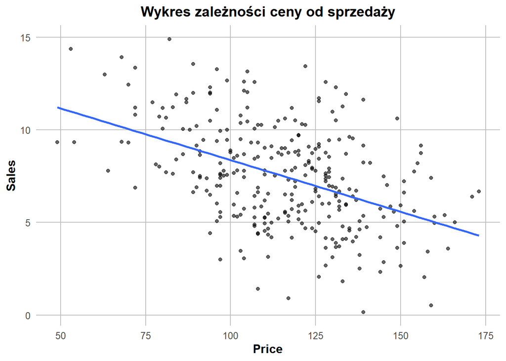

```r
ggplot(carseats_train, aes(x=Price, y=Sales)) + geom_point(size = 1.5, color = "black", alpha = 0.6) +
  geom_smooth(method='lm' ,formula=y~x, size=1, se=FALSE) +
  labs(title='Wykres zależności ceny od sprzedaży') + theme_minimal(base_size = 12) +
  theme(
    plot.title = element_text(hjust = 0.5, face = "bold"),
    axis.title = element_text(face = "bold"),
    panel.grid.major = element_line(color = "gray", size = 0.5),
    panel.grid.minor = element_blank()
  )
```

Korelacja oraz wykres wskazują na negatywną korelację.

### Sprawdzenie rozkładu reszt:

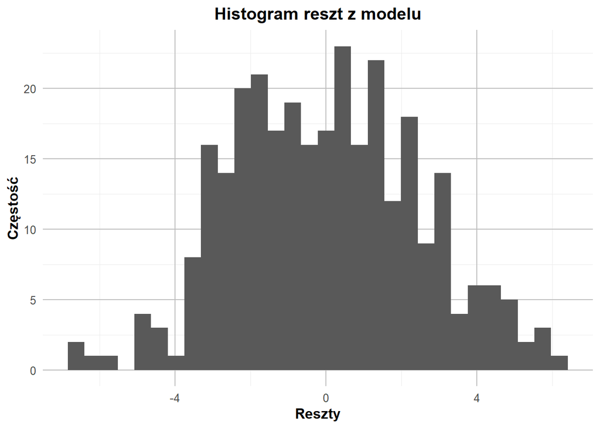

```r
ggplot(price_model, aes(x=.resid)) + geom_histogram(bins=30) +
  labs(title='Histogram reszt z modelu', x='Reszty', y='Częstość') + theme_minimal(base_size = 12) +
  theme(
    plot.title = element_text(hjust = 0.5, face = "bold"),
    axis.title = element_text(face = "bold"),
    panel.grid.major = element_line(color = "gray", size = 0.5)
  )
```

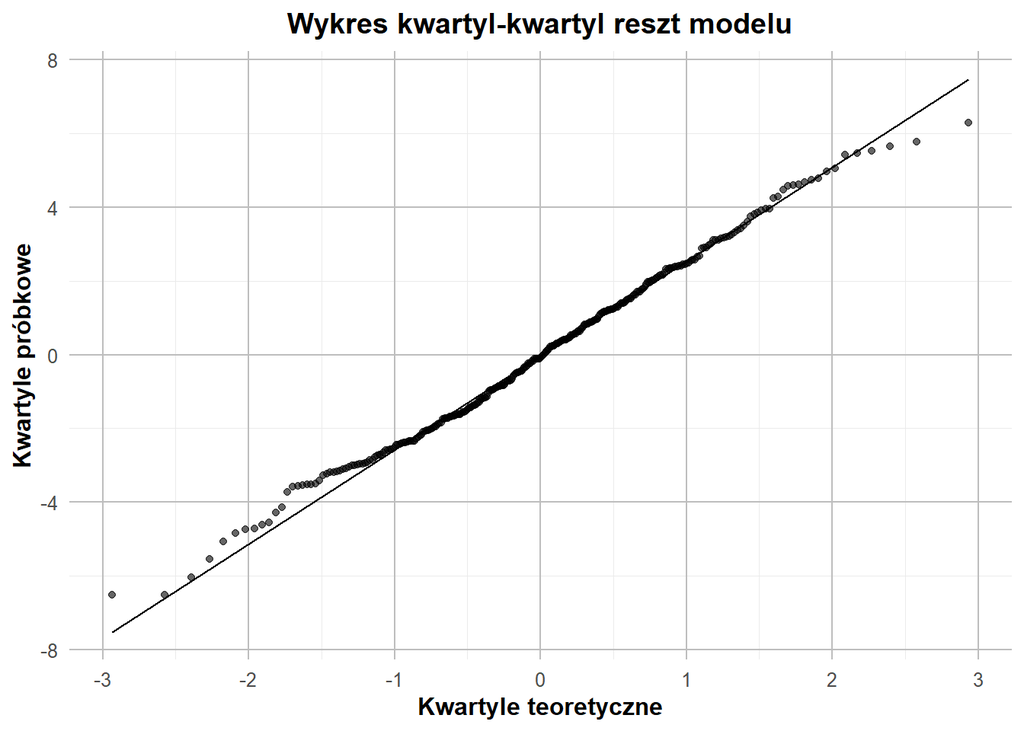

```r
ggplot(price_model, aes(sample = .resid)) +
  geom_qq(size = 1.5, color = "black", alpha = 0.6) +
  geom_qq_line() +
  labs(title = 'Wykres kwartyl-kwartyl reszt modelu',
       x = 'Kwartyle teoretyczne',
       y = 'Kwartyle próbkowe') +
  theme_minimal(base_size = 12) +
  theme(
    plot.title = element_text(hjust = 0.5, face = "bold"),
    axis.title = element_text(face = "bold"),
    panel.grid.major = element_line(color = "gray", size = 0.5)
  )
```

```r
shapiro.test(price_model$residuals)
```

```
##
##  Shapiro-Wilk normality test
##
## data:  price_model$residuals
## W = 0.99407, p-value = 0.289
```

```r
t.test(price_model$residuals)
```

```
##
##  One Sample t-test
##
## data:  price_model$residuals
## t = -4.9495e-16, df = 300, p-value = 1
## alternative hypothesis: true mean is not equal to 0
## 95 percent confidence interval:
##  -0.2799931  0.2799931
## sample estimates:
##     mean of x
## -7.042199e-17
```

Test wykazał, że należy odrzucić hipotezę alternatywną oraz możemy stwierdzić, że średnia reszt jest równa zero.

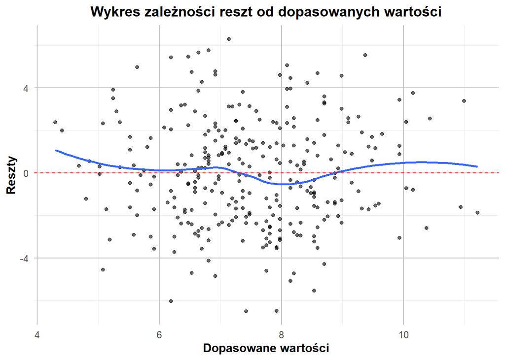

```r
ggplot(price_model, aes(.fitted, .resid)) + geom_point(size = 1.5, color = "black", alpha = 0.6) + stat_smooth(method='loess', formula=y~x, se=FALSE) +
  geom_hline(yintercept=0, linetype='dashed', color='red') +
  labs(title='Wykres zależności reszt od dopasowanych wartości', x='Dopasowane wartości',y='Reszty') + theme_minimal(base_size = 12) +
  theme(
    plot.title = element_text(hjust = 0.5, face = "bold"),
    axis.title = element_text(face = "bold"),
    panel.grid.major = element_line(color = "gray", size = 0.5)
  )
```

### Sprawdzenie niezależności reszt:

```r
lmtest::dwtest(price_model)
```

```
##
##  Durbin-Watson test
##
## data:  price_model
## DW = 1.9414, p-value = 0.3046
## alternative hypothesis: true autocorrelation is greater than 0
```

Przeprowadzony test wykazał, że p-value jest większe od $\alpha$ = 0,05 więc nie mamy dowodów, aby odrzucić hipotezę o niezależności reszt. Wartośc DW jest bliska 2 co wskazuje na brak autokorelacji.Możemy wnioskować,że założenie o niezależności reszt jest spełnione dla naszego modelu.

### Sprawdzenie homoskedatyczność:

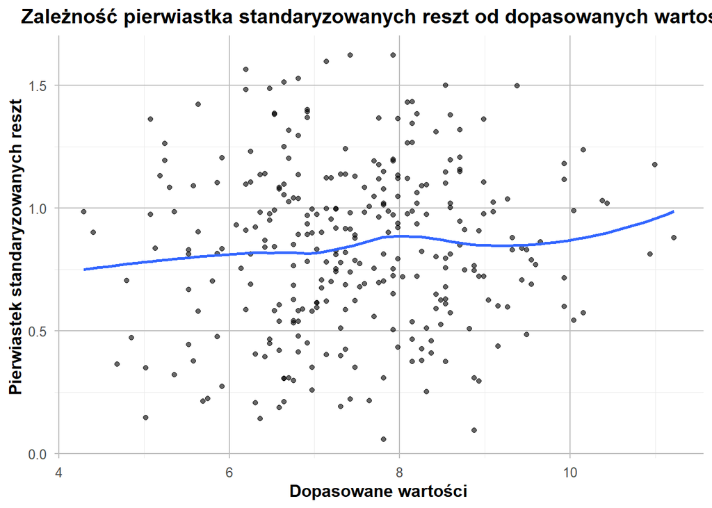

```r
ggplot(price_model, aes(.fitted, sqrt(abs(.stdresid)))) + geom_point(size = 1.5, color = "black", alpha = 0.6) + stat_smooth(method='loess', formula=y~x, se=FALSE) +
  labs(title='Zależność pierwiastka standaryzowanych reszt od dopasowanych wartości', x='Dopasowane wartości', y='Pierwiastek standaryzowanych reszt') + theme_minimal(base_size = 12) +
  theme(
    plot.title = element_text(hjust = 0.5, face = "bold"),
    axis.title = element_text(face = "bold"),
    panel.grid.major = element_line(color = "gray", size = 0.5)
  )
```

```r
lmtest::bptest(price_model)
```

```
##
##  studentized Breusch-Pagan test
##
## data:  price_model
## BP = 0.019352, df = 1, p-value = 0.8894
```

Wartość p-value wyniosłą znacznie więcej niż $\alpha$ = 0,05, oznacza to, że nie mamy istotnych dowodów heteroskedastyczności. Dlatego też możemy wnioskować,że założenie o homoskedastyczności jest prawdziwe dla naszego modelu.

### Podsumowanie modelu price:

Nasz model spełnia klasyczne założenia modelu regresji.

```r
price_model_s <- summary(price_model)
price_model_s
```

```
##
## Call:
## lm(formula = Sales ~ Price, data = carseats_train)
##
## Residuals:
##     Min      1Q  Median      3Q     Max
## -6.5113 -1.7485 -0.0897  1.6958  6.2977
##
## Coefficients:
##              Estimate Std. Error t value Pr(>|t|)
## (Intercept) 13.949676   0.747060  18.673   <2e-16 ***
## Price       -0.055798   0.006334  -8.809   <2e-16 ***
## ---
## Signif. codes:  0 '***' 0.001 '**' 0.01 '*' 0.05 '.' 0.1 ' ' 1
##
## Residual standard error: 2.473 on 299 degrees of freedom
## Multiple R-squared:  0.2061, Adjusted R-squared:  0.2034
## F-statistic: 77.61 on 1 and 299 DF,  p-value: < 2.2e-16
```

```r
test_predictions <- predict(price_model, carseats_test)
```

```r
cat('Zbiór treningowy:', '\n-MAPE:',MAPE(carseats_train$Sales, predict(price_model, carseats_train)), '\n-RMSE:', RMSE(carseats_train$Sales, predict(price_model, carseats_train)),'\n-R^2:', price_model_s$r.squared)
```

```
## Zbiór treningowy:
## -MAPE: 50.51755
## -RMSE: 2.464361
## -R^2: 0.2060689
```

```r
cat('Zbiór testowy:', '\n-MAPE:',MAPE(carseats_test$Sales, test_predictions), '\n-RMSE:', RMSE(carseats_test$Sales, test_predictions),'\n-R^2:',R_2(carseats_test$Sales, test_predictions))
```

```
## Zbiór testowy:
## -MAPE: 41.02037
## -RMSE: 2.70789
## -R^2: 0.1748445
```

## Regresja liniowa dla advertising

zakladamy ze model spelnia zalozenia

```r
adv_model <- lm(Sales ~ Advertising, data=carseats_train)
```

```r
adv_model_s <- summary(adv_model)
adv_model_s
```

```
##
## Call:
## lm(formula = Sales ~ Advertising, data = carseats_train)
##
## Residuals:
##     Min      1Q  Median      3Q     Max
## -7.2080 -1.8992 -0.0792  1.7814  8.0108
##
## Coefficients:
##             Estimate Std. Error t value Pr(>|t|)
## (Intercept)  6.88919    0.21814  31.582  < 2e-16 ***
## Advertising  0.09660    0.02455   3.935 0.000104 ***
## ---
## Signif. codes:  0 '***' 0.001 '**' 0.01 '*' 0.05 '.' 0.1 ' ' 1
##
## Residual standard error: 2.706 on 299 degrees of freedom
## Multiple R-squared:  0.04924,    Adjusted R-squared:  0.04606
## F-statistic: 15.48 on 1 and 299 DF,  p-value: 0.0001035
```

```r
test_predictions <- predict(adv_model, carseats_test)
```

```r
cat('Zbiór treningowy:', '\n-MAPE:',MAPE(carseats_train$Sales, predict(adv_model, carseats_train)), '\n-RMSE:', RMSE(carseats_train$Sales, predict(adv_model, carseats_train)),'\n-R^2:', adv_model_s$r.squared)
```

```
## Zbiór treningowy:
## -MAPE: 56.36055
## -RMSE: 2.696803
## -R^2: 0.04923643
```

```r
cat('Zbiór testowy:', '\n-MAPE:',MAPE(carseats_test$Sales, test_predictions), '\n-RMSE:', RMSE(carseats_test$Sales, test_predictions),'\n-R^2:', R_2(carseats_test$Sales,test_predictions))
```

```
## Zbiór testowy:
## -MAPE: 52.55149
## -RMSE: 2.785452
## -R^2: 0.1268976
```

Mimo że zmienna Advertising ma statystycznie istotny wpływ na sprzedaż, jakość modelu pozostaje niewystarczająca, aby uznać go za precyzyjny.

## Regresja liniowa dla age

zakladamy ze model spelnia zalozenia

```r
age_model <- lm(Sales ~ Age, data=carseats_train)
```

```r
age_model_s <- summary(age_model)
age_model_s
```

```
##
## Call:
## lm(formula = Sales ~ Age, data = carseats_train)
##
## Residuals:
##     Min      1Q  Median      3Q     Max
## -7.9898 -1.8832 -0.0326  1.7696  7.4346
##
## Coefficients:
##              Estimate Std. Error t value Pr(>|t|)
## (Intercept)  9.655286   0.531491  18.166  < 2e-16 ***
## Age         -0.040554   0.009517  -4.261 2.73e-05 ***
## ---
## Signif. codes:  0 '***' 0.001 '**' 0.01 '*' 0.05 '.' 0.1 ' ' 1
##
## Residual standard error: 2.694 on 299 degrees of freedom
## Multiple R-squared:  0.05725,    Adjusted R-squared:  0.0541
## F-statistic: 18.16 on 1 and 299 DF,  p-value: 2.728e-05
```

```r
test_predictions <- predict(age_model, carseats_test)
```

```r
cat('Zbiór treningowy:', '\n-MAPE:',MAPE(carseats_train$Sales, predict(age_model, carseats_train)), '\n-RMSE:', RMSE(carseats_train$Sales, predict(age_model, carseats_train)),'\n-R^2:', age_model_s$r.squared)
```

```
## Zbiór treningowy:
## -MAPE: 56.57889
## -RMSE: 2.685411
## -R^2: 0.05725182
```

```r
cat('Zbiór testowy:', '\n-MAPE:',MAPE(carseats_test$Sales, test_predictions), '\n-RMSE:', RMSE(carseats_test$Sales, test_predictions),'\n-R^2:',R_2(carseats_test$Sales, test_predictions))
```

```
## Zbiór testowy:
## -MAPE: 55.77424
## -RMSE: 2.913969
## -R^2: 0.04447128
```

W zbiorze treningowym MAPE wynosi 56,58%, co oznacza średni błąd prognozy na poziomie około 57%. RMSE wynosi 2,69, a $R^2$ osiąga wartość 0,057, co oznacza, że model wyjaśnia tylko około 5,7% zmienności w danych. Zmienna Age jest statystycznie istotna, co sugeruje, że wpływa na prognozowaną sprzedaż, ale jej wpływ jest ograniczony.

Zbiór testowy pokazuje marginalne pogorszenie wyników: MAPE wynosi 55,77%, RMSE osiąga wartość 2,91, a $R^2$ spada do 0,044, co oznacza, że model nie poprawia swojej wydajności na nowych danych.

Ogólnie, chociaż model wskazuje na pewną istotność zmiennej Age, jakość prognoz jest słaba, z niskim $R^2$ i wysokimi błędami prognozy. Model nie spełnia oczekiwań w kontekście precyzyjności przewidywań.

# Podsumowanie

Model oparty na zmiennej **price** (cena) wydaje się być najlepszym modelem w tym przypadku. Uzyskał najniższy **MAPE** w zbiorze testowym (41,02%) oraz stosunkowo wysokie wartości $R^2$ (0,1748) w porównaniu do innych zmiennych.